# Energy Company Stocks and Binghamton Gasoline Prices

This exploration uses five preselected U.S. companies: ExxonMobil (XOM), Chevron (CVX), Marathon Petroleum (MPC), Valero (VLO), and Phillips 66 (PSX). The first two represent integrated oil businesses; the latter three represent refining and downstream businesses. This is a representative candidate set, not a top-five ranking or a selection based on observed correlations. Stocks are distinct predictors, not substitutes spliced into a futures-price series.

## 1. Source and daily data checks

Daily historical data were retrieved from Yahoo Finance on November 3, 2026. Raw responses, close, adjusted close, and corporate-action metadata are retained. Adjusted close is used for returns to account for splits and distributions. The download starts in December 2016 to support the first weekly return of 2017. It ends November 2, 2026. No credentials are required by the download script.

```r
symbols <- c("XOM", "CVX", "MPC", "VLO", "PSX")
stocks <- list()
quality <- data.frame()
for (symbol in symbols) {
  raw <- jsonlite::fromJSON(paste0("data/raw/", symbol, ".json"),
                           simplifyVector = FALSE)$chart$result[[1]]
  number <- function(x) vapply(x, function(v) if (is.null(v)) NA_real_ else v, numeric(1))
  time <- as.POSIXct(unlist(raw$timestamp), origin = "1970-01-01", tz = "UTC")
  daily <- data.frame(date = as.Date(format(time, tz = "America/New_York", format = "%Y-%m-%d")),
    close = number(raw$indicators$quote[[1]]$close),
    adjusted_close = number(raw$indicators$adjclose[[1]]$adjclose))
  daily <- daily[order(daily$date), ]
  stopifnot(!anyDuplicated(daily$date), all(daily$adjusted_close > 0, na.rm = TRUE))
  quality <- rbind(quality, data.frame(symbol = symbol, rows = nrow(daily),
    first_date = min(daily$date), last_date = max(daily$date),
    missing_close = sum(is.na(daily$close)),
    missing_adjusted_close = sum(is.na(daily$adjusted_close))))
  write.csv(daily, paste0("data/clean/", symbol, "_daily.csv"), row.names = FALSE)

  # Keep the last observed trading day in each Monday–Friday week.
  daily <- daily[!is.na(daily$adjusted_close), ]
  day <- as.POSIXlt(daily$date)$wday
  stopifnot(all(day %in% 1:5))
  daily$week_end <- daily$date + 5 - day
  weekly <- daily[!duplicated(daily$week_end, fromLast = TRUE), ]
  # Exclude the unfinished week beginning November 2.
  weekly <- weekly[weekly$week_end <= as.Date("2026-10-30"), ]
  calendar <- data.frame(week_end = seq(min(weekly$week_end), max(weekly$week_end), by = "week"))
  weekly <- merge(calendar, weekly, by = "week_end", all.x = TRUE, sort = TRUE)
  weekly$log_return <- c(NA, diff(log(weekly$adjusted_close)))
  weekly <- weekly[weekly$week_end >= as.Date("2017-01-01"), ]
  stocks[[symbol]] <- weekly
  write.csv(weekly, paste0("data/clean/", symbol, "_weekly.csv"), row.names = FALSE, na = "")
}
knitr::kable(quality)
```

| symbol | rows | first_date | last_date | missing_close | missing_adjusted_close |
| --- | --- | --- | --- | --- | --- |
| XOM | 2493 | 2016-12-01 | 2026-11-02 | 0 | 0 |
| CVX | 2493 | 2016-12-01 | 2026-11-02 | 0 | 0 |
| MPC | 2493 | 2016-12-01 | 2026-11-02 | 0 | 0 |
| VLO | 2493 | 2016-12-01 | 2026-11-02 | 0 | 0 |
| PSX | 2493 | 2016-12-01 | 2026-11-02 | 0 | 0 |

```r
write.csv(quality, "output/data_quality.csv", row.names = FALSE)
```

Non-trading days are not missing daily observations. A holiday-shortened week uses its last actual trading day; both that date and the Friday week label are saved. Entire missing weeks would stay missing before returns are computed. Adjusted history can be revised by the provider; raw snapshots are retained for reproducibility. These are retrospective EDA data, not a vintage-correct backtest.

## 2. Stock trends and returns

For visual comparison only, adjusted prices are rebased to 100 at each stock’s first observed week of 2017. This does not change the stored prices.

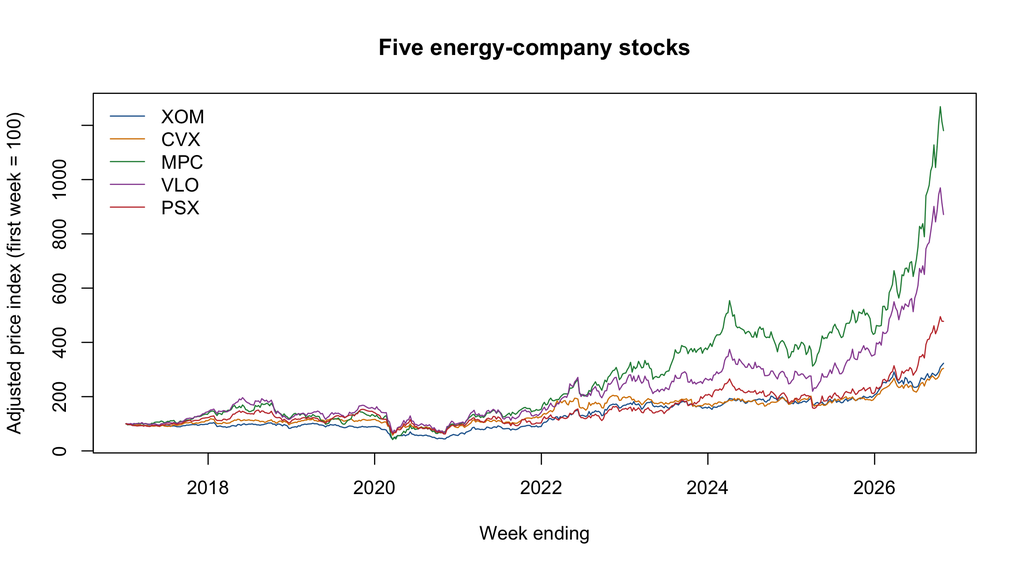

```r
colors <- c("#20639B", "#D68100", "#238B45", "#9850A0", "#C43B3B")
indexed <- sapply(stocks, function(x) 100*x$adjusted_close/x$adjusted_close[1])
matplot(stocks[[1]]$week_end, indexed, type = "l", lty = 1, col = colors,
        xlab = "Week ending", ylab = "Adjusted price index (first week = 100)",
        main = "Five energy-company stocks")
legend("topleft", symbols, col = colors, lty = 1, bty = "n")
```

```r
returns <- data.frame(week_end = stocks[[1]]$week_end)
for (symbol in symbols) {
  d <- stocks[[symbol]][, c("week_end", "log_return")]
  names(d)[2] <- symbol
  returns <- merge(returns, d, by = "week_end", all = TRUE)
}
# Equal-weight average log-return signals, not tradable portfolio indices.
returns$integrated_group <- (returns$XOM + returns$CVX)/2
returns$refining_group <- (returns$MPC + returns$VLO + returns$PSX)/3
knitr::kable(round(cor(returns[, symbols], use = "complete.obs"), 3),
             caption = "Stock weekly log-return correlations")
```

Stock weekly log-return correlations

|  | XOM | CVX | MPC | VLO | PSX |
| --- | --- | --- | --- | --- | --- |
| XOM | 1.000 | 0.836 | 0.719 | 0.716 | 0.762 |
| CVX | 0.836 | 1.000 | 0.668 | 0.702 | 0.725 |
| MPC | 0.719 | 0.668 | 1.000 | 0.860 | 0.822 |
| VLO | 0.716 | 0.702 | 0.860 | 1.000 | 0.860 |
| PSX | 0.762 | 0.725 | 0.822 | 0.860 | 1.000 |

```r
write.csv(returns, "data/clean/stock_weekly_returns.csv", row.names = FALSE, na = "")
```

## 3. Align with local weekly price changes

The local file is copied unchanged from the supplied project data. Each Monday is paired with the preceding Friday’s stock-week label. Stock returns compare successive weekly closes, not daily-average prices. Local changes compare successive Monday regional retail observations. Missing weeks are retained.

```r
local <- read.csv("data/raw/binghamton_weekly.csv")
local <- data.frame(date = as.Date(substr(local$date, 1, 10)),
                    local_price = local$binghamton_average_gal)
calendar <- data.frame(date = seq(min(local$date), max(local$date), by = "week"))
local <- merge(calendar, local, by = "date", all.x = TRUE)
local$local_change <- c(NA, diff(local$local_price))
local$local_log_change <- c(NA, diff(log(local$local_price)))
local$week_end <- local$date - 3
combined <- merge(local, returns, by = "week_end", all.x = TRUE)
combined <- combined[order(combined$date), ]
stopifnot(all(diff(combined$date) == 7), !anyDuplicated(combined$date))
write.csv(combined, "data/clean/local_stock_weekly.csv", row.names = FALSE, na = "")
```

## 4. Correlation and lag exploration

First check price levels, as suggested by Christopher. Raw closing prices and adjusted closing prices are shown separately. These level correlations can be driven by shared trends and should not be interpreted as predictive evidence.

```r
level_results <- data.frame()
for (symbol in symbols) {
  d <- merge(local, stocks[[symbol]][, c("week_end", "close", "adjusted_close")],
             by = "week_end", all.x = TRUE)
  ok <- complete.cases(d$local_price, d$close, d$adjusted_close)
  level_results <- rbind(level_results, data.frame(symbol = symbol, pairs = sum(ok),
    closing_price_correlation = cor(d$local_price[ok], d$close[ok]),
    adjusted_price_correlation = cor(d$local_price[ok], d$adjusted_close[ok])))
}
knitr::kable(level_results, digits = 3, caption = "Price-level correlations at lag 0")
```

Price-level correlations at lag 0

| symbol | pairs | closing_price_correlation | adjusted_price_correlation |
| --- | --- | --- | --- |
| XOM | 506 | 0.634 | 0.666 |
| CVX | 506 | 0.789 | 0.769 |
| MPC | 506 | 0.612 | 0.611 |
| VLO | 506 | 0.616 | 0.625 |
| PSX | 506 | 0.488 | 0.548 |

```r
write.csv(level_results, "output/stock_local_level_correlations.csv", row.names = FALSE)
```

Lag 0 pairs a Monday local change with the preceding stock week (Friday label 3 days earlier). Lag 1 moves the stock return back one additional week (Friday label 10 days earlier), and so on. Actual last trading dates can precede Friday on holidays. This is not a forecast horizon or a training-window length.

```r
features <- c(symbols, "integrated_group", "refining_group")
results <- data.frame()
for (feature in features) {
  for (lag in 0:4) {
    x <- combined[[feature]]
    if (lag > 0) x <- c(rep(NA, lag), head(x, -lag))
    ok <- complete.cases(combined$local_change, combined$local_log_change, x)
    results <- rbind(results, data.frame(feature = feature, lag = lag,
      pairs = sum(ok), first_date = min(combined$date[ok]), last_date = max(combined$date[ok]),
      change_correlation = cor(combined$local_change[ok], x[ok]),
      log_change_correlation = cor(combined$local_log_change[ok], x[ok])))
  }
}
knitr::kable(results[results$lag == 0, ], digits = 3,
             caption = "Lag 0: stock returns versus local changes")
```

Lag 0: stock returns versus local changes

|  | feature | lag | pairs | first_date | last_date | change_correlation | log_change_correlation |
| --- | --- | --- | --- | --- | --- | --- | --- |
| 1 | XOM | 0 | 505 | 2017-01-09 | 2026-09-21 | 0.089 | 0.095 |
| 6 | CVX | 0 | 505 | 2017-01-09 | 2026-09-21 | 0.114 | 0.112 |
| 11 | MPC | 0 | 505 | 2017-01-09 | 2026-09-21 | 0.062 | 0.067 |
| 16 | VLO | 0 | 505 | 2017-01-09 | 2026-09-21 | 0.075 | 0.078 |
| 21 | PSX | 0 | 505 | 2017-01-09 | 2026-09-21 | 0.043 | 0.049 |
| 26 | integrated_group | 0 | 505 | 2017-01-09 | 2026-09-21 | 0.106 | 0.108 |
| 31 | refining_group | 0 | 505 | 2017-01-09 | 2026-09-21 | 0.064 | 0.069 |

```r
write.csv(results, "output/stock_local_lag_correlations.csv", row.names = FALSE)
```

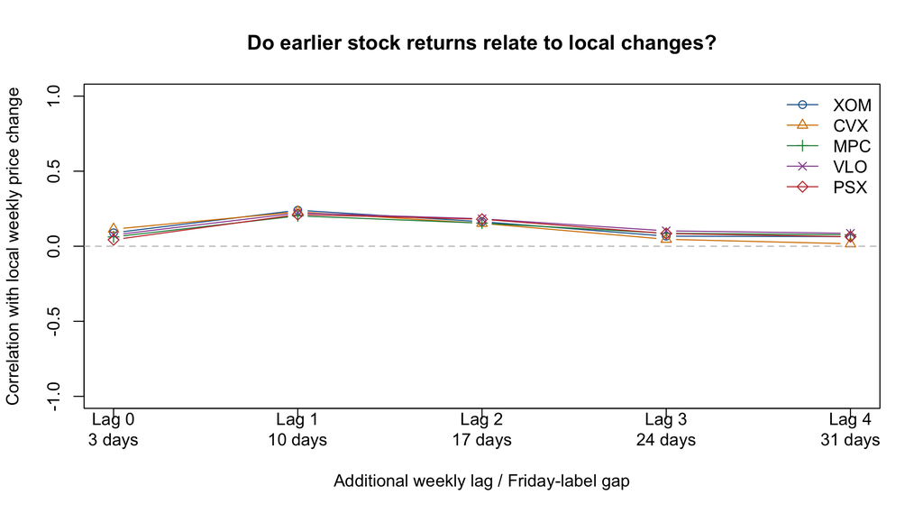

```r
plot(0:4, results$change_correlation[results$feature == "XOM"],
     type = "n", ylim = c(-1, 1), xaxt = "n",
     xlab = "Additional weekly lag / Friday-label gap",
     ylab = "Correlation with local weekly price change",
     main = "Do earlier stock returns relate to local changes?")
axis(1, 0:4, paste0("Lag ", 0:4, "\n", 3+7*(0:4), " days"))
for (i in seq_along(symbols)) {
  d <- results[results$feature == symbols[i], ]
  lines(d$lag, d$change_correlation, type = "b", pch = i, col = colors[i])
}
abline(h = 0, lty = 2, col = "gray")
legend("topright", symbols, col = colors, pch = 1:5, lty = 1, bty = "n")
```

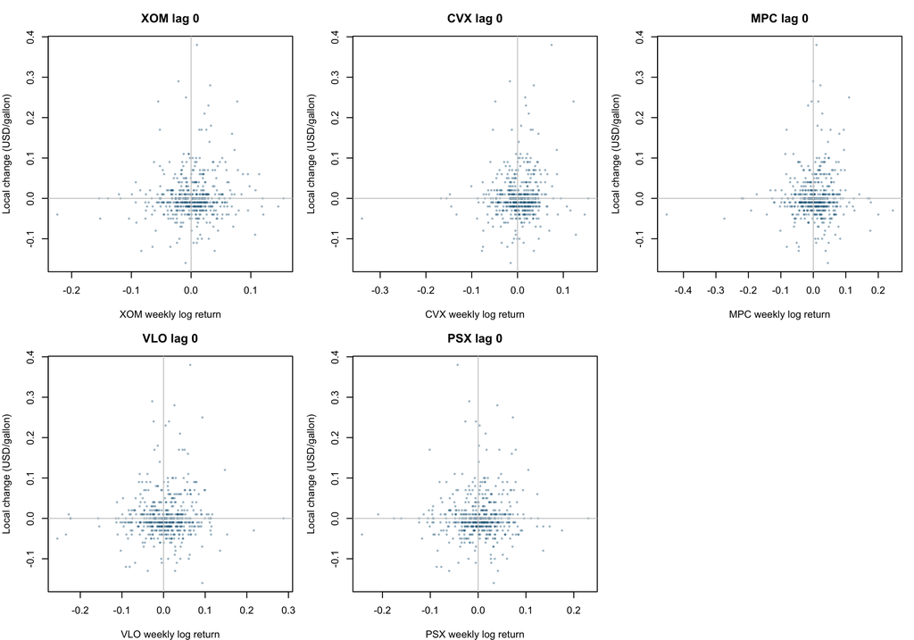

```r
par(mfrow = c(2, 3), mar = c(4, 4, 3, 1))
for (symbol in symbols) {
  plot(combined[[symbol]], combined$local_change, pch = 16, cex = 0.5,
       col = "#286A8B70", xlab = paste(symbol, "weekly log return"),
       ylab = "Local change (USD/gallon)", main = paste(symbol, "lag 0"))
  abline(h = 0, v = 0, col = "gray80")
}
```

## 5. Interpretation and limits

In this sample, lag-0 correlations between stock returns and local weekly changes are weak (about 0.04–0.11). Among the additional lags 0–4 explored, each company’s largest absolute change correlation occurs at lag 1, about 0.20–0.24. This timing pattern is an exploratory association; it does not establish significance or forecast accuracy. These are stock-return versus local-change correlations, not stock-price-level correlations, and are not directly comparable to earlier spot results unless the sample dates and definitions are held fixed.

The main question is whether equity returns provide useful information beyond local history and the already-collected spot series. Equity prices also reflect firm-specific news, distributions, and broader stock-market conditions. A correlation does not establish causality or additional forecasting value.

Results use all historical pairs and several lags, so any apparent best feature or lag is exploratory, not a validated choice. Differences between highly correlated stocks may be unstable. Group signals are optional candidates. No model has been fitted or test set used to choose variables here. A later one-week-ahead evaluation must use only data available at the forecast origin and compare against local-history and local-plus-spot baselines on identical dates.

Stock data: [Yahoo Finance XOM](https://finance.yahoo.com/quote/XOM/history/), [CVX](https://finance.yahoo.com/quote/CVX/history/), [MPC](https://finance.yahoo.com/quote/MPC/history/), [VLO](https://finance.yahoo.com/quote/VLO/history/), [PSX](https://finance.yahoo.com/quote/PSX/history/).